# Análisis y Predicción de Ventas Walmart

Dayana Serna Restrepo

``

## Planteamiento

Este proyecto analiza los datos de ventas semanales de Walmart con los dataset `train.csv` y `stores.csv` Se busca explorar el comportamiento de las ventas, identificar patrones por tienda y en el tiempo, y generar una predicción para las próximas semanas utilizando un modelo de series temporales. El dataset incluye:

- `Store`: Identificador de la tienda
- `Dept`: Departamento dentro de la tienda
- `Date`: Semana de referencia
- `Weekly_Sales`: Ventas semanales
- `IsHoliday`: Indica si la semana fue festiva

## Carga y limpieza de datos

```r
#Cargamos el csv
walmart <- read.csv(file.choose())
stores <- read.csv(file.choose())

# Convertimos columna de fecha
walmart$Date <- as.Date(walmart$Date, format="%Y-%m-%d")

#Visualizamos la data
str(walmart)
```

```
## 'data.frame':    421570 obs. of  5 variables:
##  $ Store       : int  1 1 1 1 1 1 1 1 1 1 ...
##  $ Dept        : int  1 1 1 1 1 1 1 1 1 1 ...
##  $ Date        : Date, format: "2010-02-05" "2010-02-12" ...
##  $ Weekly_Sales: num  24925 46039 41596 19404 21828 ...
##  $ IsHoliday   : logi  FALSE TRUE FALSE FALSE FALSE FALSE ...
```

```r
# Eliminamos registros con ventas negativas
walmart <- walmart %>% filter(Weekly_Sales >= 0)

## Unimos con stores.csv
data_stores <- walmart %>%
  inner_join(stores, by="Store")

head(data_stores)
```

```
##   Store Dept       Date Weekly_Sales IsHoliday Type   Size
## 1     1    1 2010-02-05     24924.50     FALSE    A 151315
## 2     1    1 2010-02-12     46039.49      TRUE    A 151315
## 3     1    1 2010-02-19     41595.55     FALSE    A 151315
## 4     1    1 2010-02-26     19403.54     FALSE    A 151315
## 5     1    1 2010-03-05     21827.90     FALSE    A 151315
## 6     1    1 2010-03-12     21043.39     FALSE    A 151315
```

```r
# Vista previa
head(walmart)
```

```
##   Store Dept       Date Weekly_Sales IsHoliday
## 1     1    1 2010-02-05     24924.50     FALSE
## 2     1    1 2010-02-12     46039.49      TRUE
## 3     1    1 2010-02-19     41595.55     FALSE
## 4     1    1 2010-02-26     19403.54     FALSE
## 5     1    1 2010-03-05     21827.90     FALSE
## 6     1    1 2010-03-12     21043.39     FALSE
```

## Ventas Totales por Tienda

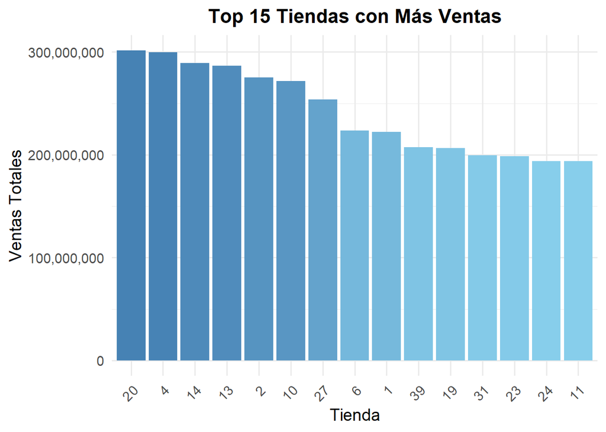

```r
ventas_tienda <- walmart %>%
  group_by(Store) %>%
  summarise(total_sales = sum(Weekly_Sales)) %>%
  arrange(desc(total_sales))

ventas_top15 <- ventas_tienda %>% head(15)

ggplot(ventas_top15, aes(x=reorder(factor(Store), -total_sales), y=total_sales, fill=total_sales)) +
  geom_col(show.legend = FALSE) +
  scale_fill_gradient(low="skyblue", high="steelblue") +
  labs(title="Top 15 Tiendas con Más Ventas", x="Tienda", y="Ventas Totales") +
  theme_minimal(base_size = 14) +
  theme(
    plot.title = element_text(face="bold", hjust=0.5, size=16),
    axis.text.x = element_text(angle=45, hjust=1)
  ) +
  scale_y_continuous(labels = scales::comma)
```

**Observación:**  
Se observa una marcada concentración de ventas en unas pocas tiendas (las de la izquierda), que superan los 250 millones en ventas totales, mientras que otras generan menos de 100 millones. Esto sugiere diferencias estructurales importantes entre las sucursales, posiblemente asociadas a ubicación, tamaño o mix de productos.

## Evolución de Ventas en el Tiempo (Todas las Tiendas)

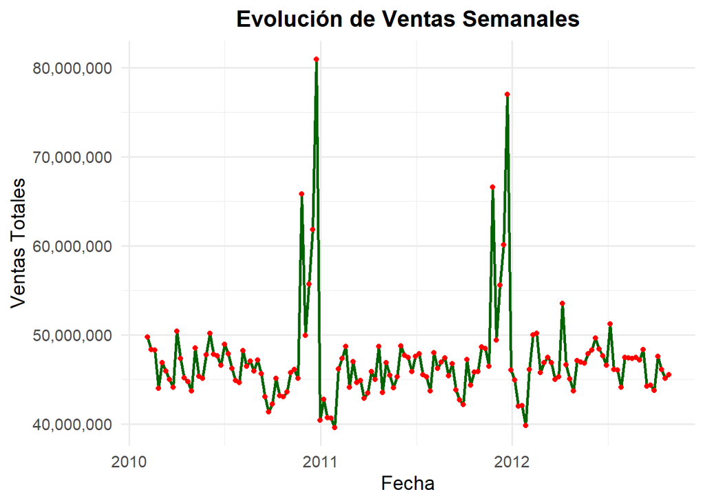

```r
ventas_fecha <- walmart %>%
  group_by(Date) %>%
  summarise(total_sales = sum(Weekly_Sales))

ggplot(ventas_fecha, aes(x=Date, y=total_sales)) +
  geom_line(color="darkgreen", size=1) +
  geom_point(color="red", size=1.5) +
  labs(title="Evolución de Ventas Semanales",
       x="Fecha",
       y="Ventas Totales") +
  theme_minimal(base_size = 14) +
  theme(plot.title = element_text(face="bold", hjust=0.5, size=16)) +
  scale_y_continuous(labels = comma)
```

**Observación:**  
La serie temporal muestra un comportamiento relativamente estable en las ventas semanales, con un rango típico entre 40 y 55 millones. Sin embargo, se destacan picos muy marcados en fechas específicas (finales de 2010 y 2011), probablemente asociados a temporadas festivas como Acción de Gracias o Navidad, lo que confirma la fuerte influencia de los periodos de alto consumo en Walmart.

## Distribución de Ventas por Departamento (Top 10)

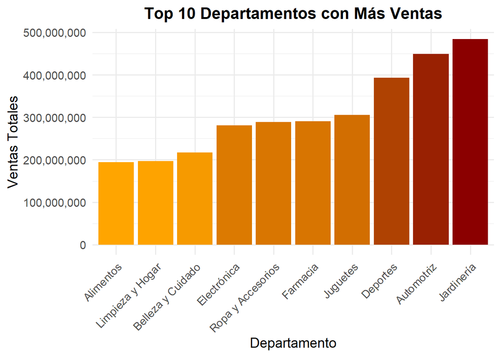

```r
dept_labels <- c(
  "2"="Electrónica",
  "8"="Alimentos",
  "13"="Limpieza y Hogar",
  "38"="Deportes",
  "40"="Ropa y Accesorios",
  "72"="Juguetes",
  "90"="Farmacia",
  "91"="Belleza y Cuidado",
  "92"="Jardinería",
  "95"="Automotriz"
)

# Top 10 departamentos con etiquetas
ventas_depto <- walmart %>%
  group_by(Dept) %>%
  summarise(total_sales = sum(Weekly_Sales)) %>%
  arrange(desc(total_sales)) %>%
  head(10)

ggplot(ventas_depto, aes(x=reorder(factor(Dept), total_sales),
                         y=total_sales, fill=total_sales)) +
  geom_col(show.legend = FALSE) +
  scale_fill_gradient(low="orange", high="darkred") +
  labs(title="Top 10 Departamentos con Más Ventas",
       x="Departamento",
       y="Ventas Totales") +
  scale_x_discrete(labels = dept_labels) +  # reemplaza los números por nombres
  theme_minimal(base_size = 14) +
  theme(
    plot.title = element_text(face="bold", hjust=0.5, size=16),
    axis.text.x = element_text(angle=45, hjust=1)
  ) +
  scale_y_continuous(labels = scales::comma)
```

**Observación:**  
Los departamentos de Jardinería y Automotriz lideran las ventas totales, superando los 400 millones cada uno. Otros departamentos relevantes son Deportes, Juguetes y Ropa y Accesorios, que muestran una fuerte contribución al ingreso. En contraste, áreas como Belleza y Cuidado y Limpieza y Hogar generan un volumen menor. Esto permite identificar cuáles líneas de negocio son estratégicas y cuáles podrían requerir impulso comercial.

## Relación entre Ventas y Tipo de Tienda

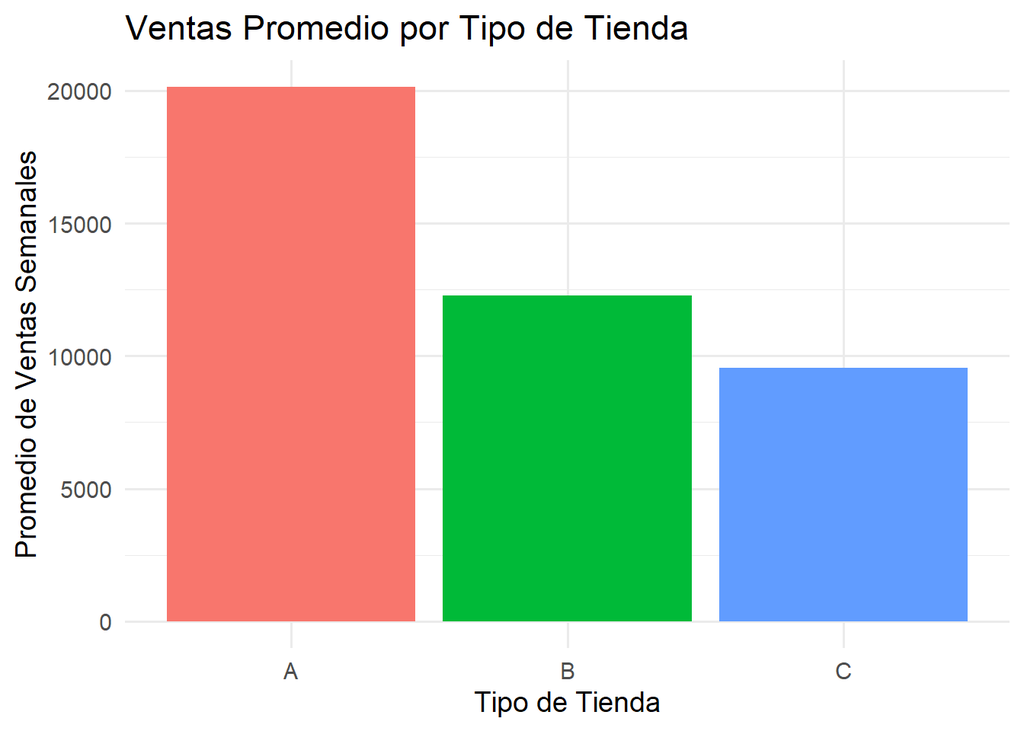

```r
ventas_tipo <- data_stores %>%
  group_by(Type) %>%
  summarise(promedio_ventas = mean(Weekly_Sales))

ggplot(ventas_tipo, aes(x=Type, y=promedio_ventas, fill=Type)) +
  geom_col(show.legend = FALSE) +
  labs(title="Ventas Promedio por Tipo de Tienda",
       x="Tipo de Tienda", y="Promedio de Ventas Semanales") +
  theme_minimal(base_size=14)
```

**Observación:** El Tipo A registra el mayor nivel de ventas promedio semanal, seguido de los tipos B y C. Esto sugiere que las tiendas tipo A concentran un mayor volumen de clientes e ingresos.

## Relación entre Tamaño de Tienda y Ventas

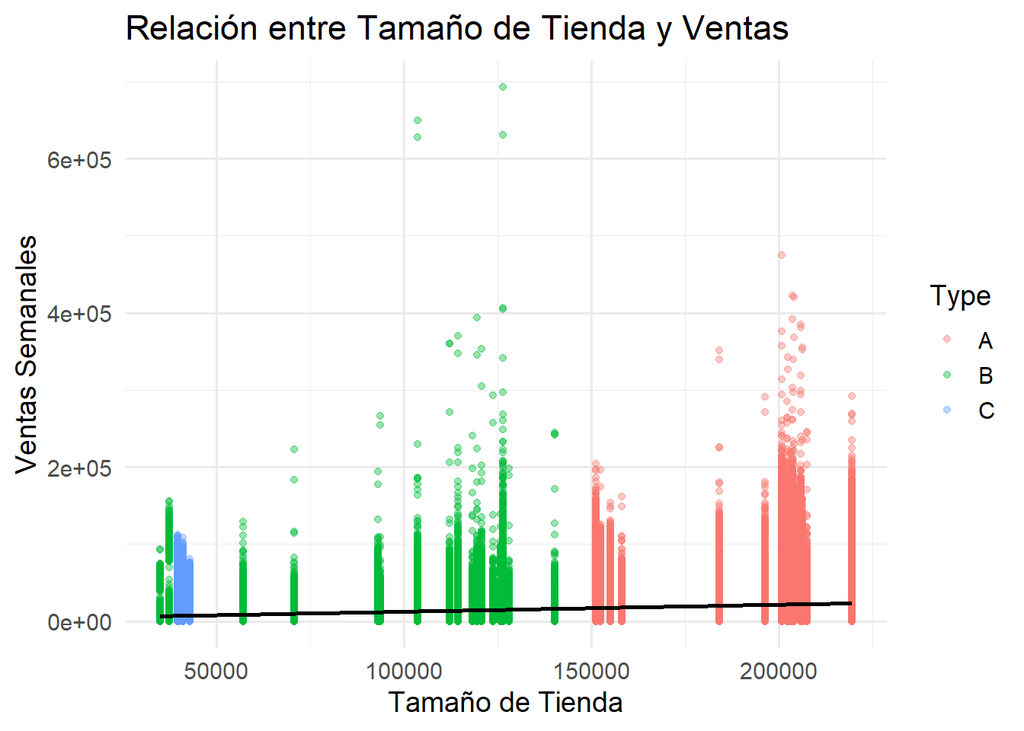

```r
ggplot(data_stores, aes(x=Size, y=Weekly_Sales, color=Type)) +
  geom_point(alpha=0.4) +
  geom_smooth(method="lm", se=FALSE, color="black") +
  labs(title="Relación entre Tamaño de Tienda y Ventas",
       x="Tamaño de Tienda", y="Ventas Semanales") +
  theme_minimal(base_size=14)
```

**Observación:** Existe una relación positiva: en general, las tiendas de mayor tamaño registran más ventas. Sin embargo, no es el único factor, ya que también influye el tipo de tienda y su localización.